# Assignment 3 Task 1

Justine Lang

2023-03-02

## Data Overview

In an exploration of country-level environmental and climatic variables, we performed a principal component analysis (PCA) on seven variables of interest in relation to the level of accessibility of cities. These data were acquired through the Google Earth Engine and were compiled and provided by zander_venter on Kaggle. Most of the data was derived by calculating the mean for each country at a reduction scale of about 10km.

Variables of interest:

- cropland cover
- tree canopy cover
- mean annual rainfall
- mean annual temperature
- annual temperature range
- wind
- cloudiness

```r
### Read in the data

env_vars <- read_csv(here("data", "world_env_vars.csv"))
```

## Data Wrangling

To further limit observations, listwise deletion was utilized. NA values were dropped before variable selection, limiting the observations from 243 to 188.

```r
### Drop NA's, clean names, and set levels for accessibility_to_cities

env_vars <- env_vars %>%
  clean_names() %>%
  drop_na() %>%
  mutate(accessibility_to_cities =
                     case_when(accessibility_to_cities <= 100 ~ "Very High",
                              accessibility_to_cities <= 500 ~ "High",
                              accessibility_to_cities <= 1000 ~ "Medium",
                              accessibility_to_cities <= 11000 ~ "Low")) %>%
  mutate(accessibility_to_cities = factor(accessibility_to_cities, levels = c('Low', 'Medium', 'High', 'Very High')))

# glimpse(env_vars)
```

For the PCA, only continuous numeric data was kept. All numeric variables were rescaled to have a mean 0 and sd 1.

```r
### Select variables of interest and scale

env_vars_pca <- env_vars %>%
  select(cropland_cover, tree_canopy_cover, rain_mean_annual, temp_mean_annual, temp_annual_range, wind, cloudiness) %>%
  dplyr::select(where(is.numeric)) %>%
  scale() %>%
  prcomp()

### See the loadings

 # env_vars_pca$rotation
```

## Biplot

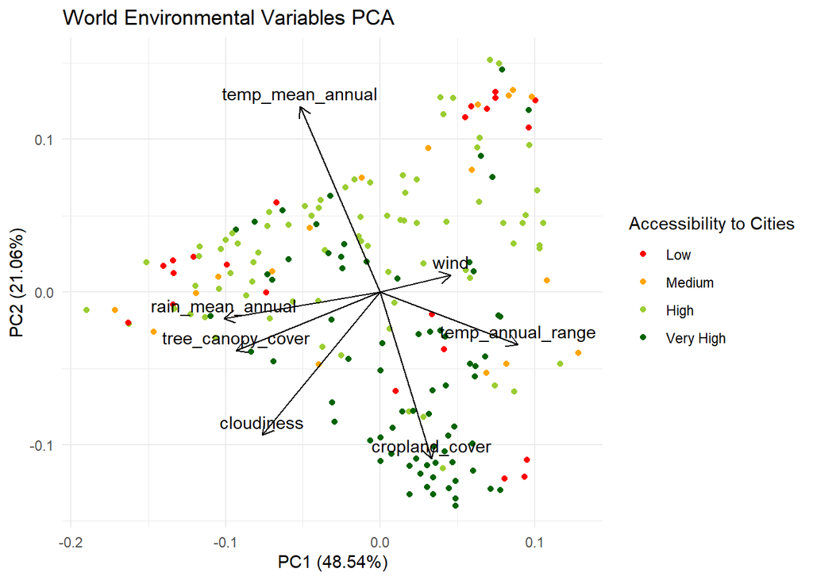

Figure 1: PCA biplot for seven country-level environmental and climatic variables. The arrows represent the loadings for PC 1 and PC 2, which together explain 69.6% of the variance. Each point, which indicates the level of accessibility to cities, is an observation based on the first two principal components.

```r
autoplot(env_vars_pca,
        data = env_vars,
        loadings = TRUE,
        colour = 'accessibility_to_cities',
        loadings.label = TRUE,
        loadings.colour = "black",
        loadings.label.colour = "black",
        loadings.label.vjust = -0.5
        ) +
  ggtitle("World Environmental Variables PCA") +
  guides(color = guide_legend(title = "Accessibility to Cities")) +
  scale_color_manual(values = c('red', 'orange', 'yellowgreen', 'darkgreen')) +
  scale_fill_manual(values = c('red', 'orange', 'yellowgreen', 'darkgreen')) +
  theme_minimal()
```

## Screeplot

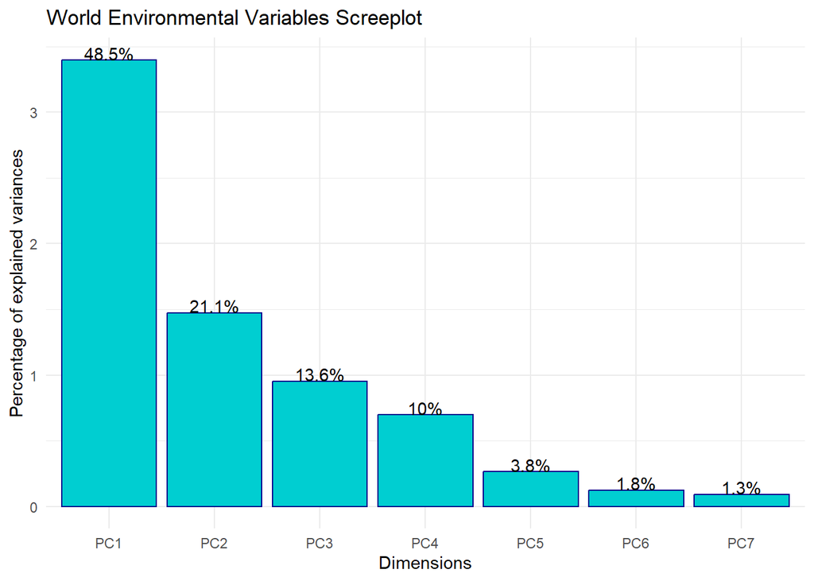

Figure 2: PCA screeplot for the country-level environmental variables. The first three PCs explain roughly 83% of the variance.

```r
sd_vec <- env_vars_pca$sdev
var_vec <- sd_vec^2 ### standard deviation is sqrt of variance
pc_names <- colnames(env_vars_pca$rotation)
pct_expl_df <- data.frame(v = var_vec,
                          pct_v = var_vec / sum(var_vec),
                          pc = fct_inorder(pc_names)) %>%
  mutate(pct_lbl = paste0(round(pct_v*100, 1), '%'))
ggplot(pct_expl_df, aes(x = pc, y = v)) +
  geom_col(color = "blue4", fill = "darkturquoise") +
  ggtitle("World Environmental Variables Screeplot")+
  geom_text(aes(label = pct_lbl), vjust = 0, nudge_y = .002) +
  labs(x = 'Dimensions', y = 'Percentage of explained variances')+
  theme_minimal()
```

## Summary

Based on these figures:

- Mean annual temperature and cropland cover are negatively correlated. These two variables also have fairly long arrows, indicating larger variance.
- Mean annual rainfall and canopy cover are the most closely correlated; more rain is correlated with more canopy.
- Wind has the shortest arrow, indicating less variance. It is also negatively correlated with mean annual rainfall and canopy cover.
- There may be some clustering of the “Very High” accessibility observations, as seen around the cropland cover arrow, but otherwise clustering is not very obvious. There may not be a strong relationship between these variables and city accessibility.
- The screeplot indicates three PCAs explain more than 80% of the variance. This may be a good cutoff point, beyond which additional components may not be as useful.

## Citation

zander_vender. 2018, Environmental variables for world countries. CC0:Public Domain. https://www.kaggle.com/datasets/zanderventer/environmental-variables-for-world-countries?select=World_countries_env_vars.csv